# Realized Higher Moment Measures of Equity Returns

Part 1: Data Preprocessing

Alexis Solis Cancino alexis.solisc@gmail.com (ITAM)  
2021-09-01

# 1. Introduction & Importing Data

We’ll work with intraday data for the *S&P/BMV IPC Equity Index*. The data consists of `n = 2,133,890` observations and `k = 23` variables. The time-series is composed of prices and trades per minute, spanning from the beginning of 1996 through the first half of 2018.

The first step is, of course, importing the data:

```r
# Read the parquet file that contains raw data
ipc_intraday <- read_parquet(file = here("data-raw/raw_MEXICO_IPC.parquet"))
```

First thing we do is take a look at the columns and data types that we have:

```r
ipc_intraday %>% glimpse()
```

```
Rows: 2,133,890
Columns: 23
$ `#RIC`                  <chr> ".MXX", ".MXX", ".MXX", ".MXX", ".MX~
$ `Date[L]`               <dbl> 19960102, 19960102, 19960102, 199601~
$ `Time[L]`               <time> 08:36:00, 08:38:00, 08:39:00, 08:40~
$ Type                    <chr> "Intraday 1Min", "Intraday 1Min", "I~
$ Open                    <dbl> 2777.47, 2777.47, 2777.47, 2777.47, ~
$ High                    <dbl> 2777.47, 2777.47, 2777.47, 2777.47, ~
$ Low                     <dbl> 2777.47, 2777.47, 2777.47, 2777.47, ~
$ Last                    <dbl> 2777.47, 2777.47, 2777.47, 2777.47, ~
$ Volume                  <dbl> 0, 0, 0, 0, 0, 0, 0, 0, 0, 0, 0, 0, ~
$ `Ave. Price`            <dbl> 2777.470, 2777.470, 2777.470, 2777.4~
$ VWAP                    <lgl> NA, NA, NA, NA, NA, NA, NA, NA, NA, ~
$ `No. Trades`            <dbl> 1, 2, 3, 3, 3, 3, 3, 3, 3, 3, 3, 3, ~
$ `Correction Qualifiers` <lgl> NA, NA, NA, NA, NA, NA, NA, NA, NA, ~
$ `Open Bid`              <lgl> NA, NA, NA, NA, NA, NA, NA, NA, NA, ~
$ `High Bid`              <lgl> NA, NA, NA, NA, NA, NA, NA, NA, NA, ~
$ `Low Bid`               <lgl> NA, NA, NA, NA, NA, NA, NA, NA, NA, ~
$ `Close Bid`             <lgl> NA, NA, NA, NA, NA, NA, NA, NA, NA, ~
$ `No. Bids`              <dbl> 0, 0, 0, 0, 0, 0, 0, 0, 0, 0, 0, 0, ~
$ `Open Ask`              <lgl> NA, NA, NA, NA, NA, NA, NA, NA, NA, ~
$ `High Ask`              <lgl> NA, NA, NA, NA, NA, NA, NA, NA, NA, ~
$ `Low Ask`               <lgl> NA, NA, NA, NA, NA, NA, NA, NA, NA, ~
$ `Close Ask`             <lgl> NA, NA, NA, NA, NA, NA, NA, NA, NA, ~
$ `No. Asks`              <dbl> 0, 0, 0, 0, 0, 0, 0, 0, 0, 0, 0, 0, ~
```

So we have `boolean`, `character`, `numeric` and `time` types of columns. We also note that the names are not very friendly to work with. We fix that by creating a *string* vector and using that to replace the names in our data. The new names are:

```r
# Create vector with new column names
column_names <- c("ticker","raw_date","raw_time","type",
                  "open","high","low","last","volume",
                  "average_price","vwap","no_trades",
                  "correction_qualifiers","open_bid",
                  "high_bid","low_bid","close_bid",
                  "no_bids","open_ask","high_ask","low_ask",
                  "close_ask","no_ask")

# Rename the columns
ipc_intraday <- ipc_intraday %>% set_names(column_names)

# Print names
ipc_intraday %>% names()
```

```
 [1] "ticker"                "raw_date"
 [3] "raw_time"              "type"
 [5] "open"                  "high"
 [7] "low"                   "last"
 [9] "volume"                "average_price"
[11] "vwap"                  "no_trades"
[13] "correction_qualifiers" "open_bid"
[15] "high_bid"              "low_bid"
[17] "close_bid"             "no_bids"
[19] "open_ask"              "high_ask"
[21] "low_ask"               "close_ask"
[23] "no_ask"
```

## 1.1 Missing values

There seem to be many missing values in the data, so let’s count them! We do this per column:

```r
map_df(ipc_intraday, ~ sum(is.na(.x))) %>%
  pivot_longer(
    cols = everything(),
    names_to = "variable",
    values_to = "missing_count"
  ) %>%
  arrange(-missing_count) %>%
  print(n = 23L)
```

```
# A tibble: 23 x 2
   variable              missing_count
   <chr>                         <int>
 1 vwap                        2133890
 2 correction_qualifiers       2133890
 3 open_bid                    2133890
 4 high_bid                    2133890
 5 low_bid                     2133890
 6 close_bid                   2133890
 7 open_ask                    2133890
 8 high_ask                    2133890
 9 low_ask                     2133890
10 close_ask                   2133890
11 ticker                            0
12 raw_date                          0
13 raw_time                          0
14 type                              0
15 open                              0
16 high                              0
17 low                               0
18 last                              0
19 volume                            0
20 average_price                     0
21 no_trades                         0
22 no_bids                           0
23 no_ask                            0
```

We see that there are 10 columns that have all values as `NA`, therefore we can remove all of these variables. The variables to remove are:

```r
# Get which columns have all values as NAs.
columns_to_remove <- map_df(ipc_intraday, ~ sum(is.na(.))) %>%
  pivot_longer(cols = everything(),
               names_to = "variable",
               values_to = "no_missing") %>%
  filter(no_missing > 0) %>%
  pull(variable)

# Print the selected columns.
columns_to_remove
```

```
 [1] "vwap"                  "correction_qualifiers"
 [3] "open_bid"              "high_bid"
 [5] "low_bid"               "close_bid"
 [7] "open_ask"              "high_ask"
 [9] "low_ask"               "close_ask"
```

Thus, our data is now leaner, and it includes the following variables:

```r
# Get a new dataset without the selected columns
ipc_intraday <- ipc_intraday %>% select(-all_of(columns_to_remove))

# Print names
ipc_intraday %>% names()
```

```
 [1] "ticker"        "raw_date"      "raw_time"      "type"
 [5] "open"          "high"          "low"           "last"
 [9] "volume"        "average_price" "no_trades"     "no_bids"
[13] "no_ask"
```

# 2. Feature Engineering & Data Wrangling

We then carry on with the analysis by creating some new variables (a.k.a. *Feature Engineering*) and manipulating the data. The first manipulations we do are the following:

1. First, a `tidy_date` variable is created, where the date is parsed according to the *ISO 8601* standard that states that dates should be expressed in the `YYYY-MM-DD` format. In consequence, the `raw_date` column is dropped and is replaced by the newly created `tidy_date` variable.
2. The `raw_time` column is replaced for the `tidy_time` variable, which parses the time correctly.
3. The `no_bids`, `no_ask`, `average_price`, `ticker`, `type`, `open`, `high`, and `low` columns are removed because (we think) they are of no use for the analysis.
4. We rename the `last` variable as `last_price`.

```r
ipc_intraday <- ipc_intraday %>%

  # Create time variables: tidy_date, tidy_time, tidy_dttm
  mutate(tidy_date = lubridate::ymd(raw_date),
         tidy_time = hms::as_hms(raw_time)
         ) %>%

  # Remove some columns
  select(-c(raw_date, raw_time, ticker, type, open, high, low, no_bids, no_ask, average_price)) %>%

  # Get newly created variable to the beginning of tibble
  relocate(starts_with("tidy"), .before = 1) %>%

  # Rename "last" variable
  rename(last_price = last)

# Print the new dataset
ipc_intraday
```

```
# A tibble: 2,133,890 x 5
   tidy_date  tidy_time last_price volume no_trades
   <date>     <time>         <dbl>  <dbl>     <dbl>
 1 1996-01-02 08:36          2777.      0         1
 2 1996-01-02 08:38          2777.      0         2
 3 1996-01-02 08:39          2777.      0         3
 4 1996-01-02 08:40          2777.      0         3
 5 1996-01-02 08:41          2777.      0         3
 6 1996-01-02 08:42          2777.      0         3
 7 1996-01-02 08:43          2777.      0         3
 8 1996-01-02 08:44          2777.      0         3
 9 1996-01-02 08:45          2777.      0         3
10 1996-01-02 08:46          2777.      0         3
# ... with 2,133,880 more rows
```

## 2.1 Exploring the time window for prices

Now, let’s explore both the `tidy_date` and `tidy_time` variables. First, it’s useful to see how many unique dates (i.e. the number of trading-days) are present in the data.

```r
n_days <- ipc_intraday %>%
  distinct(tidy_date) %>%
  nrow()

# Print the number of days
n_days %>% format(big.mark = ",")
```

```
[1] "5,613"
```

So we have 5,613 different trading-days.

Now, regarding the `tidy_time` variable, the data shows that we have prices from **05:32 a.m.** all the way through **08:22 p.m.**

```r
earliest_times <- ipc_intraday %>%
  select(tidy_time) %>%
  unique() %>%
  arrange(tidy_time) %>%
  head() %>%
  pull()

latest_times <- ipc_intraday %>%
  select(tidy_time) %>%
  unique() %>%
  arrange(desc(tidy_time)) %>%
  head() %>%
  pull()

tibble(
  earliest = earliest_times,
  latest = latest_times
)
```

```
# A tibble: 6 x 2
  earliest latest
  <time>   <time>
1 05:32    20:22
2 05:33    20:21
3 06:32    20:20
4 06:33    20:19
5 06:34    20:18
6 06:35    20:17
```

We can also visualize how many datapoints we have, per hour.

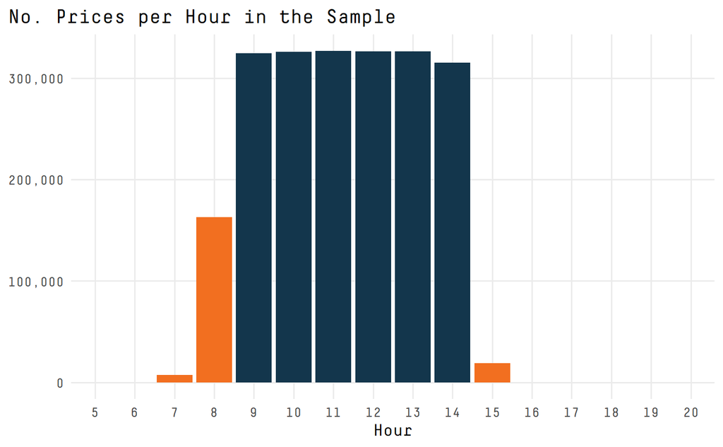

```r
ipc_intraday %>%
  mutate(tidy_hour = as.factor(hour(tidy_time))) %>%
  count(tidy_hour, sort = T, name = "trades_per_hour") %>%
  # mutate(tidy_hour = fct_reorder(tidy_hour, .x = trades_per_hour, .desc = T)) %>%
  ggplot(aes(tidy_hour, trades_per_hour)) +
  geom_col(aes(fill = between(x = as.numeric(tidy_hour),
                              left = 5,
                              right = 10)),
           show.legend = F) +
  scale_fill_manual(values = amazing_colors[c(2,8)]) +
  scale_y_continuous(labels = scales::number_format(big.mark = ",")) +
  labs(
    title = "No. Prices per Hour in the Sample",
    x = "Hour",
    y = NULL
  )
```

From the plot above, we see that most of the prices lie between 8:00AM - 3:00PM. It’s interesting that the hours `8` and `15` have fewer datapoints. We can further inspect each one to see the hour-minute components of those trades.

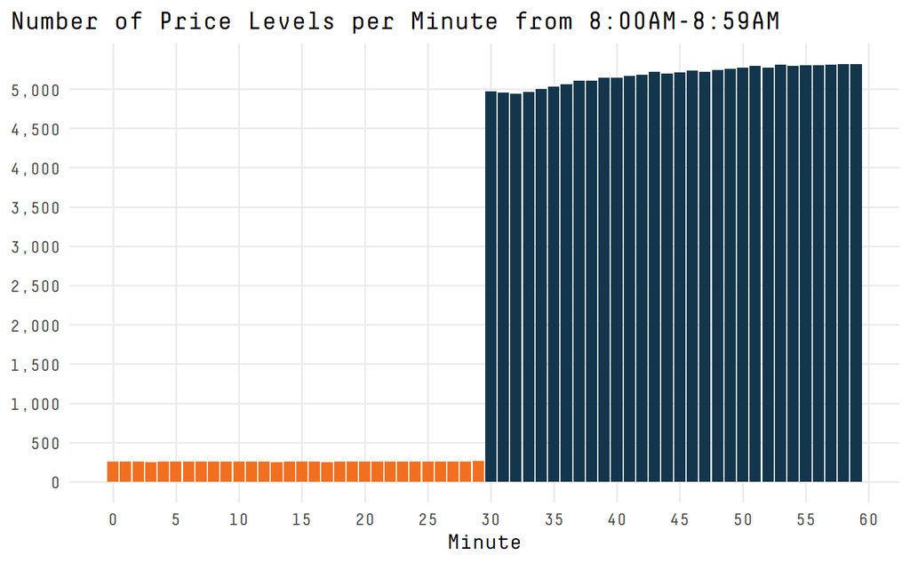

```r
ipc_intraday %>%
  mutate(tidy_hour = as.factor(hour(tidy_time)),
         tidy_minute = minute(tidy_time)) %>%
  filter(tidy_hour == 8) %>%
  count(tidy_minute, sort = T, name = "trades_per_minute") %>%
  ggplot(aes(tidy_minute, trades_per_minute)) +
  geom_col(aes(fill = tidy_minute < 30),
           show.legend = F) +
  scale_fill_manual(values = amazing_colors[c(8,2)]) +
  scale_x_continuous(breaks = seq(0, 60, 5)) +
  scale_y_continuous(
    labels = scales::number_format(big.mark = ","),
    breaks = seq(0, 5000, length.out = 11)
    ) +
  labs(
    title = "Number of Price Levels per Minute from 8:00AM-8:59AM",
    x = "Minute",
    y = NULL
  )
```

As expected, the second half-hour is the most active (that is, the period from 8:30AM - 8:59AM).

Now, let’s do the same for the `15` hour-mark:

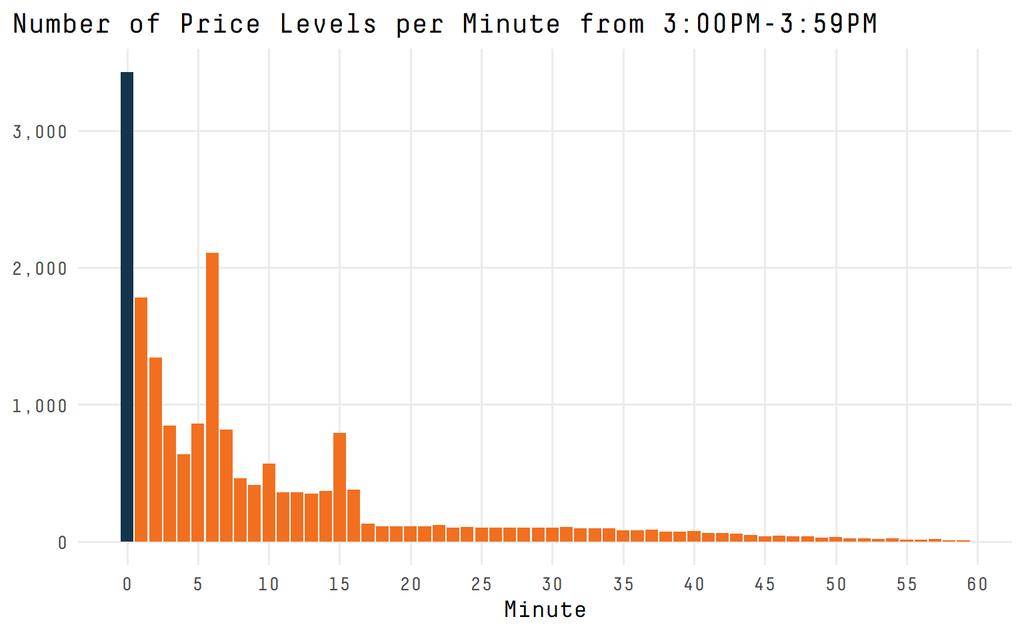

```r
ipc_intraday %>%
  mutate(tidy_hour = as.factor(hour(tidy_time)),
         tidy_minute = minute(tidy_time)) %>%
  filter(tidy_hour == 15) %>%
  count(tidy_minute, sort = T, name = "trades_per_minute") %>%
  ggplot(aes(tidy_minute, trades_per_minute)) +
  geom_col(aes(fill = trades_per_minute > 2500),
           show.legend = F) +
  scale_fill_manual(values = amazing_colors[c(2,8)]) +
  scale_x_continuous(breaks = seq(0, 60, 5)) +
  scale_y_continuous(labels = scales::number_format(big.mark = ",")) +
    labs(
    title = "Number of Price Levels per Minute from 3:00PM-3:59PM",
    x = "Minute",
    y = NULL
  )
```

Here, the time with most trades is 3:00PM exactly. Following *Liu, Patton, Sheppard (2013)*, we’ll discard any prices that were quoted outside normal business hours. Hence, we want prices that lie between `08:30` and `15:00`.

To achieve this, we’ll introduce the concept of a *time series index*.

### 2.1.1 Time Series Index

Before we continue, we must create the so called **time series index**. To achieve this, a `dttm` (*datetime*) variable is created, which is the result of combining the `tidy_date` variable and the `tidy_time` variable. This combination gets the name of `tidy_dttm`. In this case, this is the variable by which the time series will be indexed. Below we print a small sample (first 6 rows) of this variable index:

```r
ipc_intraday <- ipc_intraday %>%

  # Add time series index: tidy_dttm
  mutate(tidy_dttm = ymd_hms(str_c(tidy_date, tidy_time))) %>%

  relocate(tidy_dttm, .before = 1)

ipc_intraday %>% select(tidy_dttm) %>% head()
```

```
# A tibble: 6 x 1
  tidy_dttm
  <dttm>
1 1996-01-02 08:36:00
2 1996-01-02 08:38:00
3 1996-01-02 08:39:00
4 1996-01-02 08:40:00
5 1996-01-02 08:41:00
6 1996-01-02 08:42:00
```

Next, in order to know the *edges* of the *datetime* variable, we can get the first and last values in the time series. We name these values `left_edge` (first value) and `right_edge` (last value), respectively.

```r
left_edge <- ipc_intraday %>%

  # Arrange in descending tidy_dttm order
  arrange(tidy_dttm) %>%

  # Get the vector
  pull(tidy_dttm) %>%

  # Get the first element of the vector
  first()

right_edge <- ipc_intraday %>%

  # Arrange in descending tidy_dttm order
  arrange(tidy_dttm) %>%

  # Get the vector
  pull(tidy_dttm) %>%

  # Get the last element of the vector
  last()

paste("The first date-time in our data is:", left_edge)
```

```
[1] "The first date-time in our data is: 1996-01-02 08:36:00"
```

```r
paste("The last date-time in our data is:", right_edge)
```

```
[1] "The last date-time in our data is: 2018-06-05 11:30:00"
```

These values are incorrect; the first value in our time-series should be `1996-01-02 08:30:00` and the last one should be: `2018-06-05 15:00:00`. The Time Series Index will be defined based on these *correct* values. These will be created as the `first_dttm` and `last_dttm` variables.

```r
first_dttm <- left_edge %>%
  as_date() %>%
  paste("08:30:00") %>%
  as_datetime()

last_dttm <- right_edge %>%
  as_date() %>%
  paste("15:00:00") %>%
  as_datetime()
```

### 2.1.2 Adjustments to the Time Series Index

Below, we print the first and last 10 values of the `ts_index` object (the *time series index*).

```r
# Make index by using vectorized function
ts_index <- tibble(

  index = timetk::tk_make_timeseries(start_date = first_dttm,
                                     end_date = last_dttm,
                                     by = "60 sec")
) %>%

  # Create date and time columns
  mutate(index_date = as_date(index),

         index_time = hms(seconds = second(index),
                          minutes = minute(index),
                          hours = hour(index)
                          )
         ) %>%

  # Filter for times between 08:30 and 15:00
  filter(index_time >= as_hms("08:30:00"),
         index_time <= as_hms("15:00:00")) %>%

  # Get rid of absent dates
  filter(index_date %in% ipc_intraday$tidy_date)

# Print first 10 values
ts_index
```

```
# A tibble: 2,194,683 x 3
   index               index_date index_time
   <dttm>              <date>     <time>
 1 1996-01-02 08:30:00 1996-01-02 08:30
 2 1996-01-02 08:31:00 1996-01-02 08:31
 3 1996-01-02 08:32:00 1996-01-02 08:32
 4 1996-01-02 08:33:00 1996-01-02 08:33
 5 1996-01-02 08:34:00 1996-01-02 08:34
 6 1996-01-02 08:35:00 1996-01-02 08:35
 7 1996-01-02 08:36:00 1996-01-02 08:36
 8 1996-01-02 08:37:00 1996-01-02 08:37
 9 1996-01-02 08:38:00 1996-01-02 08:38
10 1996-01-02 08:39:00 1996-01-02 08:39
# ... with 2,194,673 more rows
```

```r
# Print last 10 values
ts_index %>%
  arrange(desc(index))
```

```
# A tibble: 2,194,683 x 3
   index               index_date index_time
   <dttm>              <date>     <time>
 1 2018-06-05 15:00:00 2018-06-05 15:00
 2 2018-06-05 14:59:00 2018-06-05 14:59
 3 2018-06-05 14:58:00 2018-06-05 14:58
 4 2018-06-05 14:57:00 2018-06-05 14:57
 5 2018-06-05 14:56:00 2018-06-05 14:56
 6 2018-06-05 14:55:00 2018-06-05 14:55
 7 2018-06-05 14:54:00 2018-06-05 14:54
 8 2018-06-05 14:53:00 2018-06-05 14:53
 9 2018-06-05 14:52:00 2018-06-05 14:52
10 2018-06-05 14:51:00 2018-06-05 14:51
# ... with 2,194,673 more rows
```

Note that we’ve removed the dates that don’t match those from the original data. This gets rid of weekends, too.

### 2.1.3 Joining the Data

We will make some checks further down the line, but for now, the data is ready to be **joined** into a new object, so that we have **no gaps** in between the 1-minute prices.

```r
ipc_intraday <- ts_index %>%
  left_join(
    ipc_intraday,
    by = c("index" = "tidy_dttm")) %>%

  # Remove useless columns
  select(-c(tidy_date, tidy_time))
```

Below, we print the first 10 rows of this joined data. It’s evident that many prices have an `NA` value, because they’re not available. We’ll *impute* these next.

```r
ipc_intraday
```

```
# A tibble: 2,194,683 x 6
   index               index_date index_time last_price volume
   <dttm>              <date>     <time>          <dbl>  <dbl>
 1 1996-01-02 08:30:00 1996-01-02 08:30             NA      NA
 2 1996-01-02 08:31:00 1996-01-02 08:31             NA      NA
 3 1996-01-02 08:32:00 1996-01-02 08:32             NA      NA
 4 1996-01-02 08:33:00 1996-01-02 08:33             NA      NA
 5 1996-01-02 08:34:00 1996-01-02 08:34             NA      NA
 6 1996-01-02 08:35:00 1996-01-02 08:35             NA      NA
 7 1996-01-02 08:36:00 1996-01-02 08:36           2777.      0
 8 1996-01-02 08:37:00 1996-01-02 08:37             NA      NA
 9 1996-01-02 08:38:00 1996-01-02 08:38           2777.      0
10 1996-01-02 08:39:00 1996-01-02 08:39           2777.      0
# ... with 2,194,673 more rows, and 1 more variable: no_trades <dbl>
```

## 2.2 Price Imputation

We can check how many missing prices we have in the data:

```r
ipc_intraday %>%
  filter(is.na(last_price)) %>%
  count() %>%
  pull(n) %>%
  format(big.mark = ",")
```

```
[1] "91,696"
```

So we have almost 92K missing prices, which represent a little over 4% of the total data. Therefore, it is acceptable if we impute the prices. We also have missing data for `volume` and number of trades (`no_trades`). These can be imputed easily: substituting a zero everytime there’s no price data (this is a reasonable imputation). First, let’s check how many missing values we have per column:

```r
ipc_intraday %>%
  map_df(.f = ~ sum(is.na(.))) %>%
  pivot_longer(
    cols = everything(),
    names_to = "variable",
    values_to = "missing_count"
    )
```

```
# A tibble: 6 x 2
  variable   missing_count
  <chr>              <int>
1 index                  0
2 index_date             0
3 index_time             0
4 last_price         91696
5 volume             91696
6 no_trades          91696
```

We now impute the volume and number of trades and check that indeed there are no missing values:

```r
# Impute volume and no_trades
ipc_intraday <- ipc_intraday %>%
  mutate(
    volume = if_else(is.na(last_price), 0, volume),
    no_trades = if_else(is.na(last_price), 0, no_trades)
  )

ipc_intraday %>%
  map_df(.f = ~ sum(is.na(.))) %>%
  pivot_longer(
    cols = everything(),
    names_to = "variable",
    values_to = "missing_count"
    )
```

```
# A tibble: 6 x 2
  variable   missing_count
  <chr>              <int>
1 index                  0
2 index_date             0
3 index_time             0
4 last_price         91696
5 volume                 0
6 no_trades              0
```

Except for the first 6 data points, we will impute the prices by looking at the last available price. For the first 6 data points, we take a look at the first non-missing price, and use that one as a replacement value.

```r
# Impute first 6 prices
ipc_intraday$last_price[1:6] <- ipc_intraday$last_price[7]

# Impute the rest of the prices using fill()
ipc_intraday <- ipc_intraday %>%
  fill(last_price)

ipc_intraday %>%
  map_df(.f = ~ sum(is.na(.))) %>%
  pivot_longer(
    cols = everything(),
    names_to = "variable",
    values_to = "missing_count"
    )
```

```
# A tibble: 6 x 2
  variable   missing_count
  <chr>              <int>
1 index                  0
2 index_date             0
3 index_time             0
4 last_price             0
5 volume                 0
6 no_trades              0
```

Another check we can do is to count the number of prices per unique date. We can do this by just counting the frequency of each date. It must have a frequency of 391, since we have:

$$\begin{equation}
\text{prices/day} = \text{hours} \times \text{minutes} + 1 = (6.5) \times 60 + 1 = 391
\end{equation}$$

```r
ipc_intraday %>%
  count(index_date, name = "date_count")
```

```
# A tibble: 5,613 x 2
   index_date date_count
   <date>          <int>
 1 1996-01-02        391
 2 1996-01-03        391
 3 1996-01-04        391
 4 1996-01-05        391
 5 1996-01-08        391
 6 1996-01-09        391
 7 1996-01-10        391
 8 1996-01-11        391
 9 1996-01-12        391
10 1996-01-15        391
# ... with 5,603 more rows
```

Printing the first 10 counts for each date… this looks correct. But now, let’s get the unique values from that `date_count` column just to be sure:

```r
ipc_intraday %>%
  count(index_date, name = "date_count") %>%
  distinct(date_count)
```

```
# A tibble: 1 x 1
  date_count
       <int>
1        391
```

The time series has been successfully padded.

## 2.3 Time Series Signature

```r
ipc_intraday <- ipc_intraday %>%

  # Create time series signature
  mutate(
    index_num   = as.numeric(index),
    diff        = index_num - lag(index_num),
    year        = year(index),
    half        = semester(index, with_year = FALSE),
    quarter     = quarter(index),
    month       = month(index),
    month_label = month(index, label = TRUE),
    day         = day(index),
    hour        = hour(index),
    minute      = minute(index),
    wday        = wday(index, week_start = 1),
    wday_label  = wday(index, label = TRUE),
    qday        = qday(index),
    yday        = yday(index),
    # mweek       =
    # week        = lubridate::week(),
    # mday7       = day %% 7,
    date_change = if_else(index_date == lag(index_date), FALSE, TRUE)
  )
```

Lastly, we do a quick check for:

1. The time series signature doesn’t contain weekend days. We check this by printing the unique values for the weekday label stored in the `wday_label` variable.

```r
ipc_intraday %>%
  distinct(wday_label)
```

```
# A tibble: 5 x 1
  wday_label
  <ord>
1 Tue
2 Wed
3 Thu
4 Fri
5 Mon
```

```r
# First 10 unique values
earliest_index <- ipc_intraday %>%
  distinct(index_time) %>%
  head() %>%
  pull(index_time)

# Last 10 unique values
latest_index <- ipc_intraday %>%
  arrange(-index_time) %>%
  distinct(index_time) %>%
  head() %>%
  pull(index_time)

tibble(
  earliest = earliest_index,
  latest = latest_index
)
```

```
# A tibble: 6 x 2
  earliest latest
  <time>   <time>
1 08:30    15:00
2 08:31    14:59
3 08:32    14:58
4 08:33    14:57
5 08:34    14:56
6 08:35    14:55
```

## 2.4 Computing Intraday Log-Returns

We are finally ready to compute the intraday returns. We name the column `log_ret`.

```r
ipc_intraday <- ipc_intraday %>%

  # Compute log-returns
  mutate(log_ret = log(last_price) - lag(log(last_price))) %>%

  # Relocate the columns
  relocate(index_date, index_time, log_ret, everything())

ipc_intraday
```

```
# A tibble: 2,194,683 x 22
   index_date index_time log_ret index               last_price volume
   <date>     <time>       <dbl> <dttm>                   <dbl>  <dbl>
 1 1996-01-02 08:30           NA 1996-01-02 08:30:00      2777.      0
 2 1996-01-02 08:31            0 1996-01-02 08:31:00      2777.      0
 3 1996-01-02 08:32            0 1996-01-02 08:32:00      2777.      0
 4 1996-01-02 08:33            0 1996-01-02 08:33:00      2777.      0
 5 1996-01-02 08:34            0 1996-01-02 08:34:00      2777.      0
 6 1996-01-02 08:35            0 1996-01-02 08:35:00      2777.      0
 7 1996-01-02 08:36            0 1996-01-02 08:36:00      2777.      0
 8 1996-01-02 08:37            0 1996-01-02 08:37:00      2777.      0
 9 1996-01-02 08:38            0 1996-01-02 08:38:00      2777.      0
10 1996-01-02 08:39            0 1996-01-02 08:39:00      2777.      0
# ... with 2,194,673 more rows, and 16 more variables:
#   no_trades <dbl>, index_num <dbl>, diff <dbl>, year <dbl>,
#   half <int>, quarter <int>, month <dbl>, month_label <ord>,
#   day <int>, hour <int>, minute <int>, wday <dbl>,
#   wday_label <ord>, qday <dbl>, yday <dbl>, date_change <lgl>
```

## 2.5 Setting Overnight Returns to NA

For modeling purposes, we will assume that there is no overnight return. Therefore, we set the first log-return of each day to `NA`. The value `NA` is chosen because it will be useful for data-wrangling purposes.

```r
ipc_intraday <- ipc_intraday %>%

  mutate(log_ret = ifelse(test = date_change == FALSE,
                          yes = log_ret,
                          no = NA))
```

We should only have one `NA` value per day. Let’s check that it is the case. We do that by checking that both numbers are equal, if that’s the case, we’ll get a `TRUE` value as output.

```r
total_na <- ipc_intraday %>%
  filter(is.na(log_ret)) %>%
  nrow()

total_dates <- ipc_intraday %>%
  distinct(index_date) %>%
  nrow()

# Check for equality
all.equal(total_na, total_dates)
```

```
[1] TRUE
```

We can check that all overnight returns are `NA`s. The variable `date_change` from the *time series index* is useful here. We extract the distinct values of the `log_ret` variable along with the `date_change` variable. We should get that all values for `date_change` are `TRUE`, and all values for `log_ret` are `NA`.

```r
ipc_intraday %>%
  filter(date_change == 1) %>%
  distinct(log_ret, date_change)
```

```
# A tibble: 1 x 2
  log_ret date_change
    <dbl> <lgl>
1      NA TRUE
```

Moreover, the number of overnight returns that have been set to `NA` should be one less than the number of different dates we have for the `tidy_date` variable. Let’s check if this holds true:

```r
ipc_intraday %>%
  filter(date_change == TRUE) %>%
  select(index_date, log_ret, date_change) %>%
  nrow() %>%
  format(big.mark = ",")
```

```
[1] "5,612"
```

We have *5,612* datapoints where `date_change = TRUE`. This should be one less than the amount of different dates (one less because the first date doesn’t have `date_change` set to one).

```r
ipc_intraday %>%
  distinct(index_date) %>%
  nrow() %>%
  format(big.mark = ",")
```

```
[1] "5,613"
```

We see that this holds true. We have correctly set the overnight returns to `NA`.

## 2.6 Removing Outliers

Removing outliers in the log-return data is important. Therefore, we filter out log-returns whose absolute value is greater than some **predefined threshold**. We’ll do this again later for 5-minute returns and 30-minute returns. We define the threshold such that we don’t have anomalous 1-minute log-returns and at the same time, we are keeping ~ 99% of the original data. Log-returns that are outside of the defined threshold are immediately set to zero.

```r
# Predefined threshold
threshold <- .10

ipc_intraday <- ipc_intraday %>%

  # we keep values below the threshold
  mutate(log_ret = ifelse(test = abs(log_ret) < threshold,
                          yes = log_ret,
                          no = 0)
         )
```

In this case we’ve set the variable `threshold` to the value `.10` as having a 10% 1-minute return would be extremely rare (most probably a mistake in the data). Fortunately, in this case, we have no anomalous returns so no log-return data had to be removed.

## 2.7 Final Data

After all this preprocessing steps, we are ready to write to data to disk. We will use this preprocessed data when working on Realized Variance Analysis and Volume Analysis.

```r
# Write data to parquet
ipc_intraday %>%
  write_parquet(sink = here("data-processed/intraday_ipc.parquet"))
```